# COMPSCIX 415.2 homework 6

Quynh Tran

March 9, 2018

## R Markdown

```r
library(mosaicData)
library(tidyverse)
```

## 1. Whickham dataset.

### 1. What variables are in this data set? outcome, smoker, age

### 2. How many observations are there and what does each represent? A data frame with 1314 observations on women for the following variables: 1) outcome: survival status after 20 years (alive or dead); 2) smoker: smoking status at baseline (No or Yes); 3) age: age (in years) at the time of the first survey/.

### 3. Create a table (use the R code below as a guide) and a visualization of the relationship between smoking status and outcome, ignoring age. What do you see? Does it make sense? It does not make sense because it shows that smokers have a greater likelihood of being alive than dead.

```r
Whickham %>% count(smoker, outcome)
```

```
## # A tibble: 4 x 3
##   smoker outcome     n
##   <fct>  <fct>   <int>
## 1 No     Alive     502
## 2 No     Dead      230
## 3 Yes    Alive     443
## 4 Yes    Dead      139
```

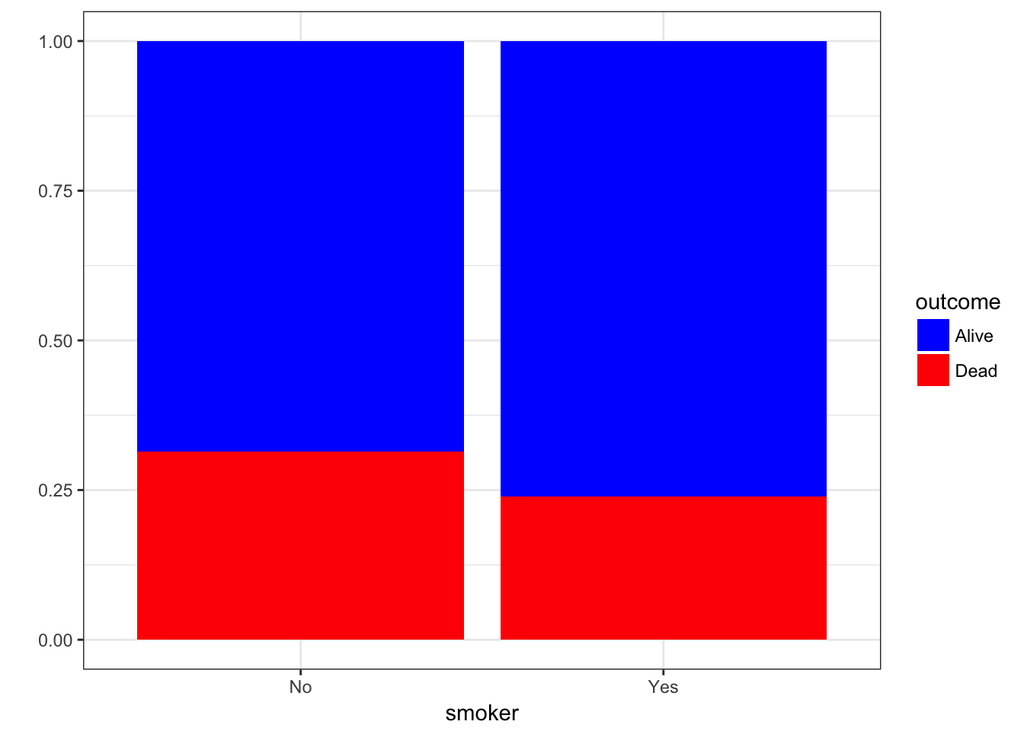

```r
Whickham %>% ggplot(aes(x = smoker, fill = outcome)) +
geom_bar(position = 'fill') +
  scale_fill_manual(values = c('blue', 'red'))+
labs(y = '') +
theme_bw()
```

```r
library(forcats)
library (dplyr)
Whickham %>% count(smoker, outcome)
```

```
## # A tibble: 4 x 3
##   smoker outcome     n
##   <fct>  <fct>   <int>
## 1 No     Alive     502
## 2 No     Dead      230
## 3 Yes    Alive     443
## 4 Yes    Dead      139
```

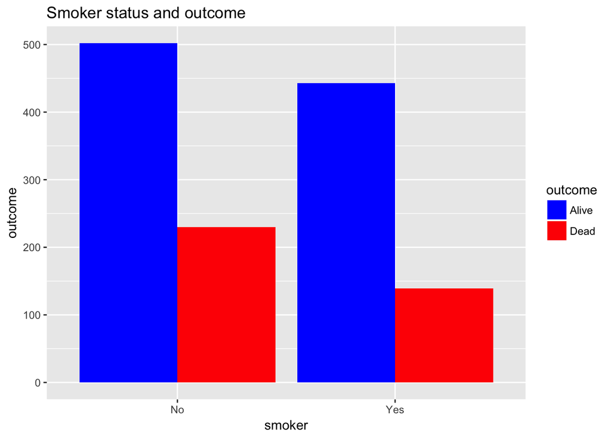

```r
smokes <-tribble(
  ~smoker, ~outcome, ~value,
"No",   "Alive",    502,
"No",   "Dead", 230,
"Yes",  "Alive",    443,
"Yes",  "Dead", 139,
)
smokes %>%
  ggplot() + geom_bar(aes(x = smoker, y = value, fill=outcome), stat = 'identity', position='dodge') +
  scale_fill_manual(values = c('blue', 'red'))+
  labs(x = 'smoker', y = 'outcome',
       title = 'Smoker status and outcome')
```

### 4. Recode the age variable into an ordered factor with three categories: age <= 44, age > 44 & age <= 64, and age > 64. Now, recreate visualization from above, but facet on your new age factor. What do you see? Does it make sense? It is still surprising that smoker status doesn’t have much affect on outcome of dead or alive. Age has a much stronger effect. The probability of death increased dramatically with age, regardless of smoker status.

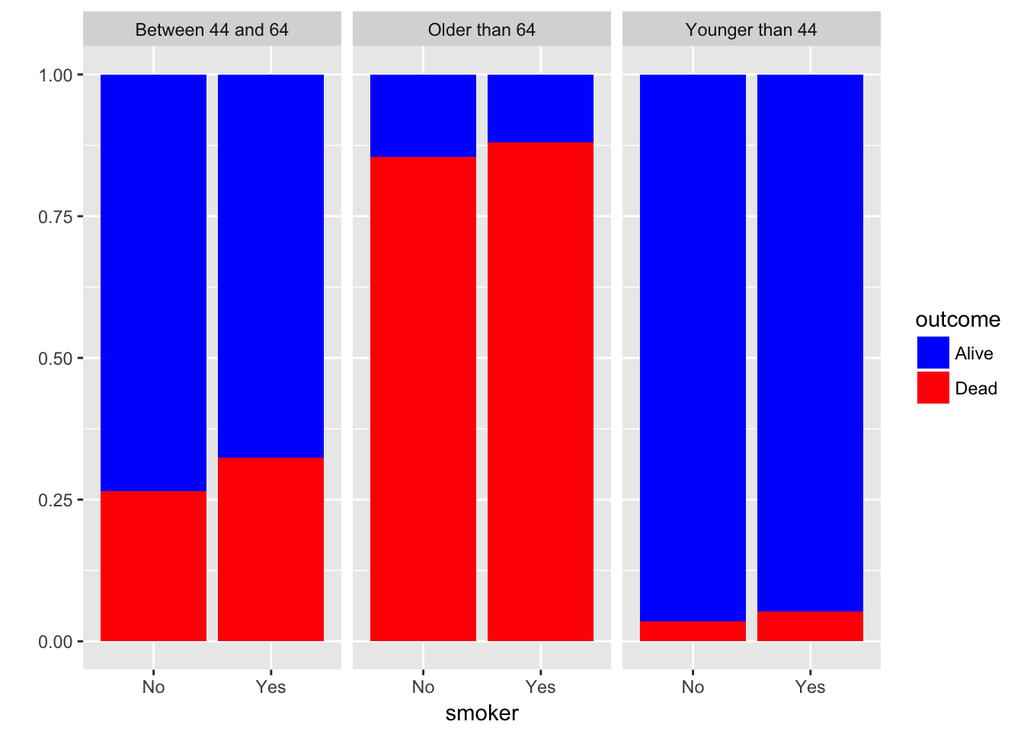

```r
Whickham%>%
  mutate(age_cat = case_when(age <= 44 ~"Younger than 44",
                   age > 44 & age <= 64 ~"Between 44 and 64",
                   age > 64~"Older than 64")) %>%
  ggplot(aes(x = smoker, fill = outcome)) +
geom_bar(position = 'fill') +
  scale_fill_manual(values = c('blue', 'red'))+
labs(y = '') +
  facet_wrap(~age_cat)
```

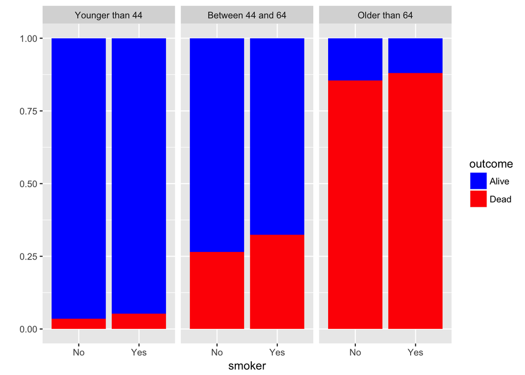

```r
Whickham%>%
  mutate(age_cat = case_when(age <= 44 ~"Younger than 44",
                   age > 44 & age <= 64 ~"Between 44 and 64",
                   age > 64~"Older than 64"), age_cat= fct_relevel(age_cat,"Younger than 44", "Between 44 and 64","Older than 64" )) %>%
  ggplot(aes(x = smoker, fill = outcome)) +
geom_bar(position = 'fill') +
  scale_fill_manual(values = c('blue', 'red'))+
labs(y = '') +
  facet_wrap(~age_cat)
```

# Exercise 2

## The Central Limit Theorem states that the sampling distribution of sample means is approximately Normal, regardless of the distribution of your population. For this exercise our population distribution will be a Gamma(1,2) distribution, and we’ll show that the sampling distribution of the mean is in fact normally distributed.

### 1. Generate a random sample of size n = 10000 from a gamma(1,2) distribution and plot a histogram or density curve. Use the code below to help you get your sample.

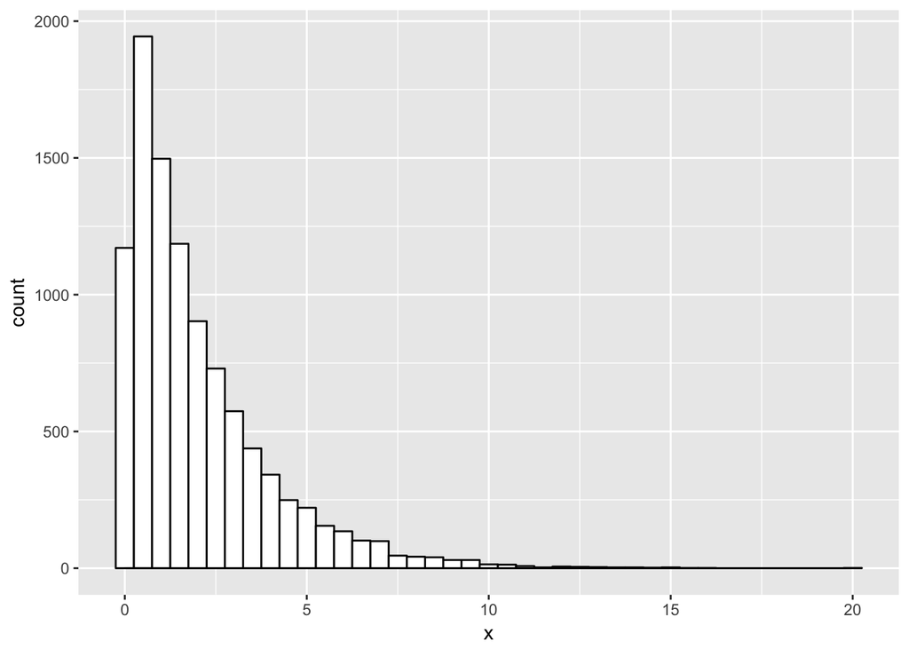

```r
n<-10000
gamma_samp <- tibble(x=rgamma(n,shape=1,scale=2))

ggplot(gamma_samp, aes(x = x))+
  geom_histogram(binwidth=.5, colour="black", fill="white")+
  geom_density(alpha=.2, fill="#FF6666")
```

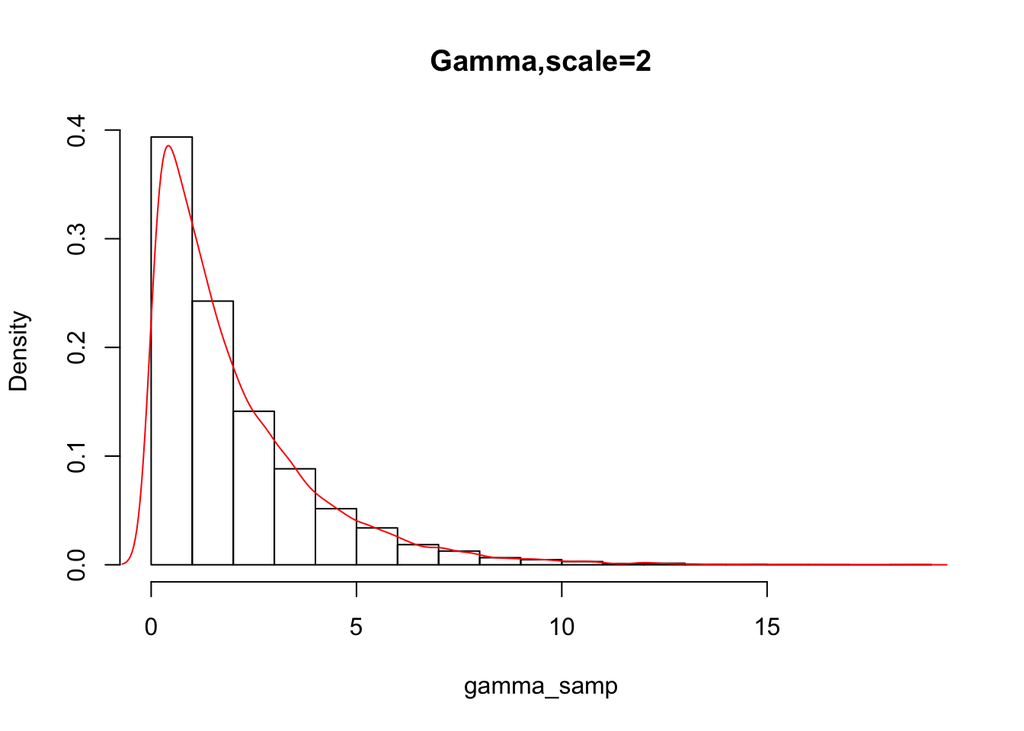

```r
n<-10000
gamma_samp <- rgamma(n,shape=1,scale=2)

hist(gamma_samp,prob=T,main='Gamma,scale=2')
lines(density(gamma_samp),col='red')
```

```r
library(tidyverse)

n <-10000
gamma_samp <- tibble(x = rgamma(n, shape = 1, scale = 2))
  mean_samp <- gamma_samp %>% .[['x']] %>% mean()
  std_samp <- gamma_samp %>% .[['x']] %>% sd()
  mean_samp
```

```
## [1] 1.995872
```

```r
  std_samp
```

```
## [1] 2.008822
```

```r
library(mosaicData)

library(tidyverse)

n <-10000
gamma_samp <- tibble(x = rgamma(n, shape = 1, scale = 2)) %>%

summarize(mean_random = mean(x, na.rm = TRUE),
                        sd_random= sd(x, na.rm = TRUE))

gamma_samp
```

```
## # A tibble: 1 x 2
##   mean_random sd_random
##         <dbl>     <dbl>
## 1        1.99      2.00
```

### 3. Pretend the distribution of our population of data looks like the plot above. Now take a sample of size n = 30 from a Gamma(1,2) distribution, plot the histogram or density curve, and calculate the mean and standard deviation.

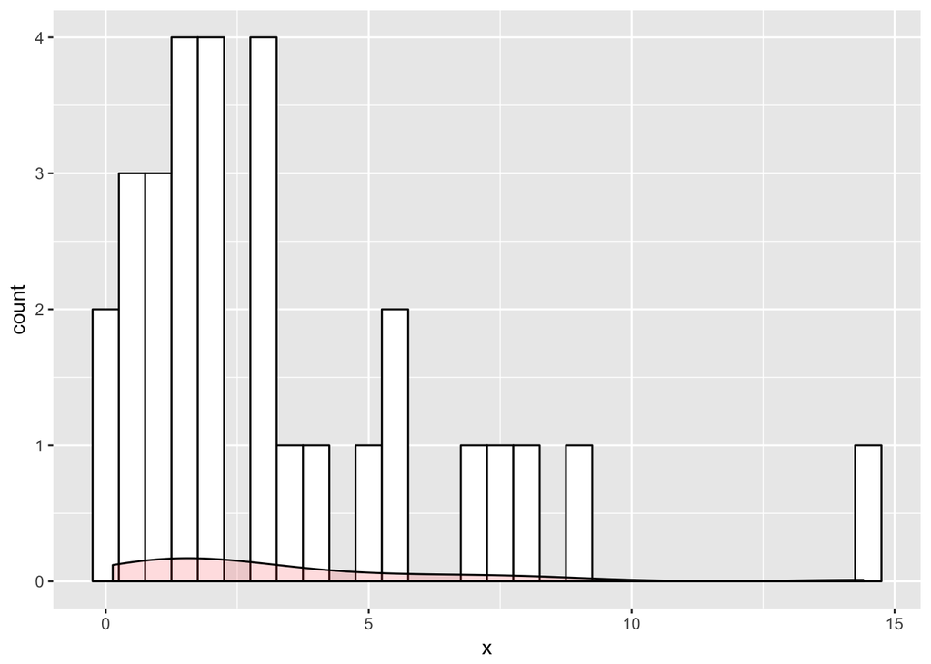

```r
n<-30
gamma_samp <- tibble(x=rgamma(n,shape=1,scale=2))

ggplot(gamma_samp, aes(x = x))+
  geom_histogram(binwidth=.5, colour="black", fill="white")+
  geom_density(alpha=.2, fill="#FF6666")
```

```r
n<-30
gamma_samp <- tibble(x=rgamma(n,shape=1,scale=2))
  mean_samp <-gamma_samp %>%.[['x']]%>% mean()
   std_samp <-gamma_samp %>%.[['x']]%>% sd()
  mean_samp
```

```
## [1] 2.615971
```

```r
  std_samp
```

```
## [1] 2.791893
```

## Robert, please tell me how this coding makes the results different from the previous coding you suggested? Using summarize () instead of ‘mean_samp <-gamma_samp %>%.[[’x’]]%>% mean()’

```r
n30 <-30
gamma_samp <- tibble(x = rgamma(n30, shape = 1, scale = 2)) %>%

summarize(mean_random = mean(x, na.rm = TRUE),
                        sd_random= sd(x, na.rm = TRUE))

gamma_samp
```

```
## # A tibble: 1 x 2
##   mean_random sd_random
##         <dbl>     <dbl>
## 1        2.44      2.36
```

```r
n30 <-30
gamma_samp <- rgamma(n30,shape=1,scale=2)
mean(gamma_samp)
```

```
## [1] 2.410755
```

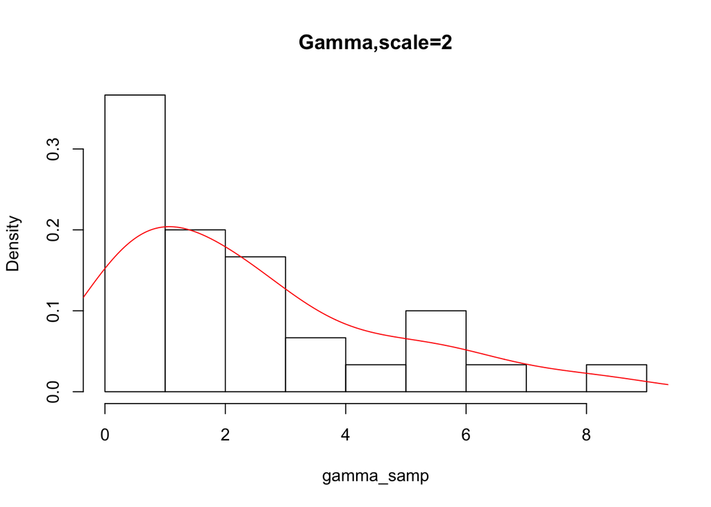

```r
hist(gamma_samp,prob=T,main='Gamma,scale=2')
lines(density(gamma_samp),col='red')
```

### 4. Take a sample of size n = 30, again from the Gamma(1,2) distribution, calculate the mean, and assign it to a vector named mean_samp. Repeat this 10000 times! The code below might help.

```r
n<-30
gamma_samp <- tibble(x=rgamma(n,shape=1,scale=2))

# create a vector with 10000 NAs
mean_samp <- rep(NA, 10000)
# start a loop
for(i in 1:10000) {
g_samp <- rgamma(30, shape = 1, scale = 2)
mean_samp[i] <- mean(g_samp)
}

# Convert vector to a tibble
mean_samp <- tibble(mean_samp)
```

5. Make a histogram of your collection of means from above (mean_samp).

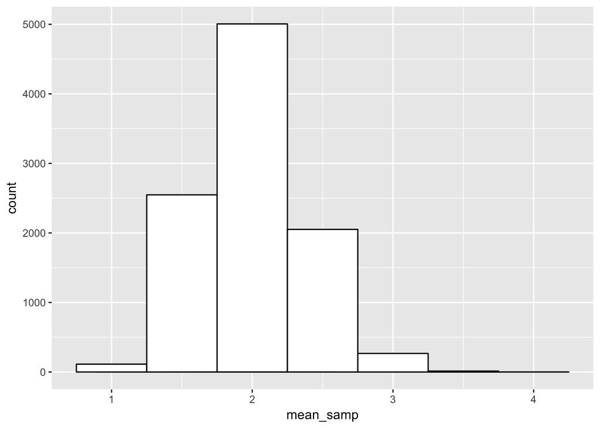

```r
n<-30
gamma_samp <- tibble(x=rgamma(n,shape=1,scale=2))

# create a vector with 10000 NAs
mean_samp <- rep(NA, 10000)
# start a loop
for(i in 1:10000) {
g_samp <- rgamma(30, shape = 1, scale = 2)
mean_samp[i] <- mean(g_samp)
}

# Convert vector to a tibble
mean_samp <- tibble(mean_samp)


ggplot(mean_samp, aes(x = mean_samp))+
  geom_histogram(binwidth=.5, colour="black", fill="white")+
  geom_density(alpha=.2, fill="#FF6666")
```

## 6. Calculate the mean and standard deviation of all of your sample means.

```r
n <-30
gamma_samp <- tibble(x=rgamma(n,shape=1,scale=2))

# create a vector with 10000 NAs
mean_samp <- rep(NA, 10000)
# start a loop
for(i in 1:10000) {
g_samp <- rgamma(30, shape = 1, scale = 2)
mean_samp[i] <- mean(g_samp)
}

# Convert vector to a tibble
mean_samp <- tibble(mean_samp)


mean_samp%>%
summarize(mean_samp = mean(mean_samp, na.rm = TRUE),
                        sd_samp= sd(mean_samp, na.rm = TRUE))
```

```
## # A tibble: 1 x 2
##   mean_samp sd_samp
##       <dbl>   <dbl>
## 1      2.00      NA
```

```r
n <-30
gamma_samp <- tibble(x=rgamma(n,shape=1,scale=2))

# create a vector with 10000 NAs
mean_samp <- rep(NA, 10000)
# start a loop
for(i in 1:10000) {
g_samp <- rgamma(30, shape = 1, scale = 2)
mean_samp[i] <- mean(g_samp)
}

# Convert vector to a tibble
mean_samp <- tibble(mean_samp)

mean_samp <-mean_samp %>%.[['mean_samp']]%>% mean()



  mean_samp
```

```
## [1] 1.999345
```

```r
  std_samp
```

[output not shown]

### 7. Did anything surprise you about your answers to #6? The larger the sample, the more accurate the sample means and std to the true population mean and std. When your sample size is only 30, your mean and std is not very accurate. However with repeated samples of size 30, the collection of sample mean and std, even though small, should approximate to the true population mean and std.

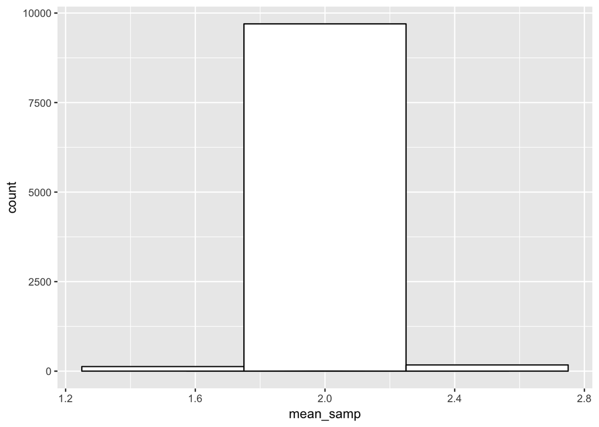

```r
n<-300
gamma_samp <- tibble(x=rgamma(n,shape=1,scale=2))

# create a vector with 10000 NAs
mean_samp <- rep(NA, 10000)
# start a loop
for(i in 1:10000) {
g_samp <- rgamma(300, shape = 1, scale = 2)
mean_samp[i] <- mean(g_samp)
}

# Convert vector to a tibble
mean_samp <- tibble(mean_samp)

ggplot(mean_samp, aes(x = mean_samp))+
  geom_histogram(binwidth=.5, colour="black", fill="white")+
  geom_density(alpha=.2, fill="#FF6666")
```

```r
mean_samp%>%
summarize(mean_samp = mean(mean_samp, na.rm = TRUE),
                        sd_samp= sd(mean_samp, na.rm = TRUE))
```

```
## # A tibble: 1 x 2
##   mean_samp sd_samp
##       <dbl>   <dbl>
## 1      2.00      NA
```